# BvCategorical Example

Aaron J. Molstad (amolstad@ufl.edu)

10/13/2021

In this document, we provide a short tutorial on how to use the $\texttt{BvCategorical}$ R package. **If you encounter any errors or strange behavior, please report the issue at https://github.com/ajmolstad/BvCategorical**.

First, we install the $\texttt{BvCategorical}$ R package from GitHub.

```r
install.packages("devtools")
library(devtools)
devtools::install_github("ajmolstad/BvCategorical")
library(BvCategorical)
```

## Data generating model

Next, we generate data from the bivariate categorical response regression model. Here, the responses are $J$-category and $K$-category multinomial random variables with a single trial per subject. Generalizing to multiple trials per subject is trivial: users need only append additional rows to $X$ and $Y$ so that the data are formatted as if there were only a single trial per subject. To keep computing times short, we use $J=3$ and $K=2$ in the following example.

Recall, under the bivariate multinomial logistic regression model, $\boldsymbol{\beta} \in \mathbb{R}^{p + 1 \times J \times K}$ where
$$P(Y_{1i} = j, Y_{2i} = k \mid x_i) = \frac{\exp\left(x_i'\boldsymbol{\beta}_{\cdot, j, k} \right)}{\sum_{s,t} \exp\left(x_i'\boldsymbol{\beta}_{\cdot, s, t} \right)}, \quad\quad(i,j,k) \in \left\{1, \dots, n\right\} \times \left\{1, \dots, J\right\} \times \left\{1,\dots, K\right\}.$$
where $x_i = (1, x_{1i}, \dots, x_{pi})$ for $i=1, \dots, n$.

In the following, we generate $\boldsymbol{\beta}$ so that six variables modify the joint probability mass function, i.e., they uniquely modify $P(Y_{1i} = j, Y_{2i} = k \mid x_i)$; four modify only the marginal probabilities $P(Y_{1i} = j\mid x_i)$ and $P(Y_{2i} = k \mid x_i)$, and the rest do not affect the response.

```r
# --------------------------------
# Preliminaries
# --------------------------------
set.seed(10)
p <- 200
n <- 500
J <- 3
K <- 2
ntest <- 1e4
Results <- NULL

SigmaX <- matrix(0, nrow=p, ncol=p)
for(jj in 1:p){
  for(kk in 1:p){
    SigmaX[jj,kk] <- .5^abs(jj-kk)
  }
}
eo <- eigen(SigmaX)
SigmaXsqrt <- eo$vec%*%diag(eo$val^.5)%*%t(eo$vec)

X <- matrix(rnorm(n*p), nrow=n)%*%SigmaXsqrt
Xtest <- matrix(rnorm(ntest*p), nrow=ntest)%*%SigmaXsqrt

# generated data -------------
X <- matrix(rnorm(n*p), nrow=n)%*%SigmaXsqrt
Xtest <- matrix(rnorm(ntest*p), nrow=ntest)%*%SigmaXsqrt

beta <- matrix(0, nrow=p, ncol=J*K)
temp <- sample(1:p, 10)

# joint probabilities -------------
for(j in 1:6){
  beta[temp[j],] <- runif(6, -3, 3)
}
  #  marginal probabilities only ---
for(j in 7:10){
  temp1 <- runif(4, -3, 3)
  beta[temp[j],] <- c(-temp1[4] + temp1[3] + temp1[1], temp1[1], temp1[2], temp1[3], temp1[4], -temp1[1]+ temp1[4] + temp1[2])
}

lleval <- exp(crossprod(t(X), beta))
Pmat <- lleval/(rowSums(lleval)%*%t(rep(1, J*K)))
Ymat <- matrix(0, nrow=n, ncol=J*K)
Y <- list(NA)
Y[[1]] <- rep(0, n)
Y[[2]] <- rep(0, n)
refClasses <- rbind(c(1:J, 1:J), c(rep(1, J), rep(2, J)))
for(k in 1:n){
  Ymat[k,] <- rmultinom(1, 1, Pmat[k,])
  Y[[1]][k] <- refClasses[1,which(Ymat[k,]==1)]
  Y[[2]][k] <- refClasses[2,which(Ymat[k,]==1)]
}

lleval <- exp(crossprod(t(Xtest), beta))
PmatTest <- lleval/(rowSums(lleval)%*%t(rep(1, J*K)))
YmatTest <- matrix(0, nrow=ntest, ncol=J*K)
Ytest <- list(NA)
Ytest[[1]] <- rep(0, ntest)
Ytest[[2]] <- rep(0, ntest)
refClasses <- rbind(c(1:J, 1:J), c(rep(1, J), rep(2, J)))
for(k in 1:ntest){
  YmatTest[k,] <- rmultinom(1, 1, PmatTest[k,])
  Ytest[[1]][k] <- refClasses[1,which(YmatTest[k,]==1)]
  Ytest[[2]][k] <- refClasses[2,which(YmatTest[k,]==1)]
}
```

## Model fitting

To fit the model, use the function $\texttt{BvCat.cv}$.The arguments are as follows:

- $\texttt{X}$: an $n \times p$ matrix of predictors, unstandardized. Should not include an intercept – this is done internally;
- $\texttt{Y}$: a list with two components, each corresponding to one of the two response variables. Elements of each component should be integers from $1$ to $K$ where $K$ is the number of response categories for that response;
- $\texttt{ngamma}$: the number of candidate tuning parameters $\gamma$ to consider in cross-validation/model fitting;
- $\texttt{lambda.vec}$: a vector of candidate $\lambda$ values to consider in cross-validation/model fitting;
- $\texttt{nfolds}$: the number of folds to use for cross-validation. If one would rather not perform cross-validation, setting $\texttt{nfolds = NULL}$ fits the model for each of the pairs $(\gamma, \lambda)$, but does not perform cross-validation;
- $\texttt{delta}$: a parameter between 0 and 1 indicating the ratio from largest to smallest candidate $\gamma$ value, i.e., $\min{\gamma} = \delta \max{\gamma}$;
- $\texttt{standardize}$: $\texttt{TRUE/FALSE}$ indicating whether predictors should be standardized for model fitting;
- $\texttt{tol}$: Convergence tolerance for proximal gradient descent algorithm (change in objective function value across previous three iterations);
- $\texttt{quiet}$: $\texttt{TRUE/FALSE}$ indicating whether progress should be printed after each model fit for all pairs $(\gamma, \lambda)$;
- $\texttt{inner.quiet}$: $\texttt{TRUE/FALSE}$ indicating whether progress should be printed after each iterations of the proximal gradient descent algorithm – note that this argument should only be $\texttt{TRUE}$ if users are diagnosing covergence tolerance as output can be quite verbose.

For more on formatting, we suggest following the example data generating procedure above.

```r
modfit <- BvCat.cv(X, Y, ngamma = 10,
                  lambda.vec = 10^seq(-1, -4, length=5),
                  nfolds = 5, delta = .05, standardize = TRUE,
                  tol = 1e-10,  quiet = FALSE, inner.quiet = TRUE)
```

```
## lambda =  0.1 ; gamma =  0.2558115 ; nonzero =  6
## lambda =  0.1 ; gamma =  0.1833839 ; nonzero =  12
## lambda =  0.1 ; gamma =  0.1314626 ; nonzero =  30
## lambda =  0.1 ; gamma =  0.09424177 ; nonzero =  48
## lambda =  0.1 ; gamma =  0.0675592 ; nonzero =  60
## lambda =  0.1 ; gamma =  0.04843125 ; nonzero =  66
## lambda =  0.1 ; gamma =  0.03471896 ; nonzero =  144
## lambda =  0.1 ; gamma =  0.02488902 ; nonzero =  312
## lambda =  0.1 ; gamma =  0.01784222 ; nonzero =  504
## lambda =  0.1 ; gamma =  0.01279058 ; nonzero =  714
## lambda =  0.01778279 ; gamma =  0.2558115 ; nonzero =  6
## lambda =  0.01778279 ; gamma =  0.1833839 ; nonzero =  18
## lambda =  0.01778279 ; gamma =  0.1314626 ; nonzero =  42
## lambda =  0.01778279 ; gamma =  0.09424177 ; nonzero =  48
## lambda =  0.01778279 ; gamma =  0.0675592 ; nonzero =  60
## lambda =  0.01778279 ; gamma =  0.04843125 ; nonzero =  66
## lambda =  0.01778279 ; gamma =  0.03471896 ; nonzero =  120
## lambda =  0.01778279 ; gamma =  0.02488902 ; nonzero =  240
## lambda =  0.01778279 ; gamma =  0.01784222 ; nonzero =  426
## lambda =  0.01778279 ; gamma =  0.01279058 ; nonzero =  588
## lambda =  0.003162278 ; gamma =  0.2558115 ; nonzero =  6
## lambda =  0.003162278 ; gamma =  0.1833839 ; nonzero =  24
## lambda =  0.003162278 ; gamma =  0.1314626 ; nonzero =  42
## lambda =  0.003162278 ; gamma =  0.09424177 ; nonzero =  54
## lambda =  0.003162278 ; gamma =  0.0675592 ; nonzero =  60
## lambda =  0.003162278 ; gamma =  0.04843125 ; nonzero =  66
## lambda =  0.003162278 ; gamma =  0.03471896 ; nonzero =  144
## lambda =  0.003162278 ; gamma =  0.02488902 ; nonzero =  294
## lambda =  0.003162278 ; gamma =  0.01784222 ; nonzero =  450
## lambda =  0.003162278 ; gamma =  0.01279058 ; nonzero =  618
## lambda =  0.0005623413 ; gamma =  0.2558115 ; nonzero =  6
## lambda =  0.0005623413 ; gamma =  0.1833839 ; nonzero =  24
## lambda =  0.0005623413 ; gamma =  0.1314626 ; nonzero =  42
## lambda =  0.0005623413 ; gamma =  0.09424177 ; nonzero =  54
## lambda =  0.0005623413 ; gamma =  0.0675592 ; nonzero =  60
## lambda =  0.0005623413 ; gamma =  0.04843125 ; nonzero =  66
## lambda =  0.0005623413 ; gamma =  0.03471896 ; nonzero =  204
## lambda =  0.0005623413 ; gamma =  0.02488902 ; nonzero =  366
## lambda =  0.0005623413 ; gamma =  0.01784222 ; nonzero =  534
## lambda =  0.0005623413 ; gamma =  0.01279058 ; nonzero =  708
## lambda =  1e-04 ; gamma =  0.2558115 ; nonzero =  6
## lambda =  1e-04 ; gamma =  0.1833839 ; nonzero =  24
## lambda =  1e-04 ; gamma =  0.1314626 ; nonzero =  42
## lambda =  1e-04 ; gamma =  0.09424177 ; nonzero =  54
## lambda =  1e-04 ; gamma =  0.0675592 ; nonzero =  60
## lambda =  1e-04 ; gamma =  0.04843125 ; nonzero =  72
## lambda =  1e-04 ; gamma =  0.03471896 ; nonzero =  210
## lambda =  1e-04 ; gamma =  0.02488902 ; nonzero =  378
## lambda =  1e-04 ; gamma =  0.01784222 ; nonzero =  552
## lambda =  1e-04 ; gamma =  0.01279058 ; nonzero =  726
## Through CV fold 1
## Through CV fold 2
## Through CV fold 3
## Through CV fold 4
## Through CV fold 5
```

Once we have fit the model, we can examine the output.

```r
str(modfit)
```

```
## List of 15
##  $ beta            :Formal class 'dgCMatrix' [package "Matrix"] with 6 slots
##   .. ..@ i       : int [1:9456] 0 201 402 603 804 1005 0 159 201 360 ...
##   .. ..@ p       : int [1:51] 0 6 18 48 96 156 222 366 678 1182 ...
##   .. ..@ Dim     : int [1:2] 1206 50
##   .. ..@ Dimnames:List of 2
##   .. .. ..$ : NULL
##   .. .. ..$ : NULL
##   .. ..@ x       : num [1:9456] 0.0579 0.1679 -0.106 0.3572 -0.106 ...
##   .. ..@ factors : list()
##  $ J               : int 3
##  $ K               : int 2
##  $ p               : int 200
##  $ D               : num [1:6, 1:3] 1 -1 0 -1 1 0 1 0 -1 -1 ...
##  $ standardize     : logi TRUE
##  $ errs.joint      : num [1:5, 1:10, 1:5] 0.769 0.769 0.769 0.769 0.769 ...
##  $ deviance        : num [1:5, 1:10, 1:5] 368 368 368 368 368 ...
##  $ lambda.min.joint: num 0.00316
##  $ gamma.min.joint : num 0.0249
##  $ X.mean          : num [1:200] -0.0315 -0.0502 -0.0639 0.0422 0.0317 ...
##  $ X.sd            : num [1:200] 1.02 1.008 0.967 0.971 1.039 ...
##  $ cv.index        :List of 5
##   ..$ : int [1:104] 2 28 52 83 174 180 182 190 219 231 ...
##   ..$ : int [1:100] 15 26 38 77 186 195 205 247 263 340 ...
##   ..$ : int [1:100] 5 13 31 120 153 203 235 242 257 283 ...
##   ..$ : int [1:98] 17 41 82 162 210 218 249 258 290 311 ...
##   ..$ : int [1:98] 111 116 123 132 185 194 196 225 270 330 ...
##  $ lambda.vec      : num [1:5] 0.1 0.017783 0.003162 0.000562 0.0001
##  $ gamma.vec       : num [1:10] 0.2558 0.1834 0.1315 0.0942 0.0676 ...
##  - attr(*, "class")= chr "BvCat"
```

The output contains the following (omitting those with obvious meaning):

- $\texttt{beta}:$ a sparse matrix containing the estimated regression coefficients for all pairs of tuning parameters. $\textbf{Do not}$ use these directly as they are not properly rescaled if $\texttt{standardized = TRUE}$: rather, extract coefficients using $\texttt{BvCat.coef}$ below;
- $D \in \mathbb{R}^{JK \times \binom{J}{2}\binom{K}{2}}$ is the matrix used to impose the log-odds penalty;
- $\texttt{errs.joint}$: the joint misclassification rate for the $\texttt{nfolds}$ for each candidate pair of tuning parameters;
- $\texttt{deviance}:$ the deviance for each of the $\texttt{nfolds}$;
- $\texttt{lambda.min.joint}$ the $\lambda$ value leading to smallest average misclassification rate over the $\texttt{nfolds}$;
- $\texttt{gamma.min.joint}$ the $\gamma$ value leading to smallest average misclassification rate over the $\texttt{nfolds}$;
- $\texttt{X.mean}$ and $\texttt{X.sd}$: the mean and standard deviation of the $p$ predictor variables (used for standardization/prediction in other functions);
- $\texttt{lambda.vec}$ and $\texttt{gamma.vec}$: the candidate tuning parameters $\lambda$ and $\gamma$ used for model fitting.

## Prediction and coefficient extraction

With the fitted model, an object of type $\texttt{BvCat}$, we can first examine the misclassification errors averaged over the folds:

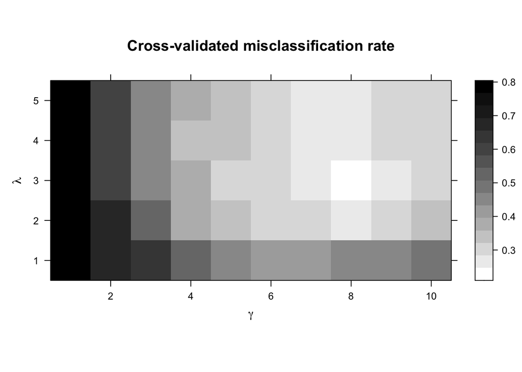

```r
library(lattice)
levelplot(t(apply(modfit$errs.joint, c(1,2), mean)), xlab=expression(paste(gamma)), ylab=expression(paste(lambda)), main="Cross-validated misclassification rate", col.regions=grey((100:0)/100))
```

Then, we can predict the classes for a new set of predictors, $\texttt{Xtest}$, using the $\texttt{BvCat.predict}$ function. By default, $\texttt{BvCat.predict}$ uses the tuning parameter pair which had the minimum average misclassification rate in cross-validation.

```r
outPred <- BvCat.predict(Xtest = Xtest, modfit, type="class") # prediction using tuning parameters which minimized classification error
```

We can also perform prediction using the fitted model for other tuning parameter pairs:

```r
devInds <- which(apply(modfit$deviance, c(1,2), mean) == min(apply(modfit$deviance, c(1,2), mean)), arr.ind=TRUE)
outPred.dev <- BvCat.predict(Xtest = Xtest, modfit, lambda = modfit$lambda.vec[devInds[1,1]], gamma = modfit$gamma.vec[devInds[1,2]]) # prediction using tuning parameters which minimized deviance

preds.mat <- apply(outPred$preds, 1, function(x){(x[1]+(J*(x[2]-1)))})
misclass.joint <- sum(apply(YmatTest, 1, which.max) != preds.mat)/length(Ytest[[1]])
cat(misclass.joint, "\n")
```

```
## 0.2487
```

```r
preds.dev.mat <- apply(outPred.dev$preds, 1, function(x){(x[1]+(J*(x[2]-1)))})
misclass.joint.dev <- sum(apply(YmatTest, 1, which.max) != preds.dev.mat)/length(Ytest[[1]])
cat(misclass.joint.dev, "\n")
```

```
## 0.2558
```

Finally, we can extract the regression coefficients using $\texttt{BvCat.coef}$. It is important to use this function rather than tryign to extracty the coefficients from the output of $\texttt{BvCat.cv}$ since $\texttt{BvCat.coef}$ will return coefficients on the original scale.

When we use the argument $\texttt{type="matrix"}$, we get the matricized version of $\hat{\boldsymbol{\beta}}$, $\hat\beta$, which is given by
$$\hat\beta_{m,f(j,k)} = \hat{\boldsymbol{\beta}}_{m,j,k}, \quad\quad (m,j,k) \in \left\{1, \dots, p+1\right\} \times \left\{1, \dots, J \right\} \times \left\{1, \dots, K\right\}.$$
where $f(j,k) = (k-1)J + j$ for $(j,k) \in \left\{1, \dots, J\right\} \times \left\{1, \dots, K\right\}.$ Note that $\boldsymbol{\beta}_0$ denotes the intercept term.

```r
outBeta <- BvCat.coef(modfit, type="matrix")
str(outBeta)
```

```
## List of 3
##  $ b0      : num [1:6] 0.09511 0.122917 -0.207627 0.239992 -0.000361 ...
##  $ beta    : num [1:200, 1:6] 0.186 0 0 0 -1.066 ...
##  $ classref: num [1:2, 1:6] 1 1 2 1 3 1 1 2 2 2 ...
```

Using the argument $\texttt{type="array"}$ instead returns $\hat{\boldsymbol{\beta}}$, the array-valued estimate.

```r
outBetaArray <- BvCat.coef(modfit, type="array")
str(outBetaArray)
```

```
## List of 3
##  $ b0      : num [1, 1:3, 1:2] 0.09511 0.122917 -0.207627 0.239992 -0.000361 ...
##  $ beta    : num [1:200, 1:3, 1:2] 0.186 0 0 0 -1.066 ...
##  $ classref: num [1:2, 1:6] 1 1 2 1 3 1 1 2 2 2 ...
```

Let’s not verify that the results of both functions agree in terms of their predicted probabilties.

```r
outPred.check <- BvCat.predict(Xtest = Xtest[1,,drop=FALSE], modfit, type="probabilities")
outCoef.check <- BvCat.coef(modfit)
l0 <- exp(outCoef.check$b0 + Xtest[1,,drop=FALSE]%*%outCoef.check$beta)
rbind(c(l0/sum(l0)),c(unlist(outPred.check))) ## both approaches agree
```

```
##       preds1    preds2    preds3     preds4      preds5     preds6
## [1,] 0.42501 0.1372561 0.3405905 0.07316204 0.008504305 0.01547703
## [2,] 0.42501 0.1372561 0.3405905 0.07316204 0.008504305 0.01547703
```